# Soc-xsit-live

Kyle MacDonald

December 7, 2014

#### Analysis code for SOC-XSIT-LIVE experiment.

Load libraries.

```r
source("/Users/kmacdonald/Documents/programming/rscripts/useful.R")
library(reshape2)
library(plyr)
library(dplyr)
library(bootstrap)
library(lme4)
library(ggplot2)
```

Read in the master data file

```r
setwd("/Users/kmacdonald/Documents/Projects/SOC_XSIT/processed_data/adult-live/")
df_live <- read.csv("soc_xsit_live.csv")
```

#### Get the number of subjects in each experiment and condition.

```
## Source: local data frame [2 x 2]
##
##        condition n_subs
## 1 No-socialFirst     96
## 2    SocialFirst     94
```

#### Filters and exclusionary criteria

Flag trials with extremely slow or fast RTs (+/- 2SD).

```r
df_live <- df_live %>%
      mutate(include_good_rt = ifelse(log(rt) > mean(log(rt)) + 2 * sd(log(rt)) |
                                            log(rt) < mean(log(rt)) - 2 * sd(log(rt)),
                                      0,1))
```

### Flag social vs. no-social trials

When we switched to within subjects, we tracked which block came first, but didn’t track social vs. no-social. So we create a column to track this information

```r
df_live <- df_live %>%
      mutate(condition_trial = ifelse(condition == "No-socialFirst"
                                      & itemNum <= 7, "no-social",
                                      ifelse(condition == "SocialFirst"
                                             & itemNum <= 7, "social",
                                             ifelse(condition == "No-socialFirst"
                                                    & itemNum >= 8, "social",
                                                    ifelse(condition == "SocialFirst"
                                                           & itemNum >= 8,
                                                           "no-social", NA)))))
```

Flag subs who got <25% of exposure trials correct. This can be used for exclusionary criteria in later analyses.

```r
# get mean acc on exposure trials for each subject
ss_exposure <- df_live %>%
      filter(trial_cat == "exposure" & condition_trial == "social") %>%
      group_by(subids) %>%
      summarise(mean_acc_exp = mean(correct))

# merge mean acc with the rest of the dataset
df_live <- merge(df_live, ss_exposure, by = "subids")
```

Flag test trials where subject chose target of eye gaze.

```r
df_test <- df_live %>%
      filter(trial_cat == "test")

# extract exposure trials and create a correct on exposure column
df_expo <- df_live %>%
      filter(trial_cat == "exposure") %>%
      mutate(correct_exposure = faceIdx == chosenIdx) %>%
      select(subids, itemNum, correct_exposure)

# join with test trials
df_test <- merge(df_test, df_expo)
df_test <- arrange(df_test, subids, itemNum)
```

#### Analyze Exposure Trials

Set up filters

```r
# just RT filter
df_exposure <- filter(df_live,
                      include_good_rt == 1,
                      condition_trial == "social",
                      trial_cat == "exposure")

# RT, subject level and trial level filter
df_exposure_filt <- filter(df_live,
                           trial_cat == "exposure",
                           condition_trial == "social" & mean_acc_exp > 0.25,
                           include_good_rt == 1)
```

Get the number of subjects filtered out

```r
#get number of subjects filtered out
df_n <- df_exposure %>%
                  summarise(n_subs = n_distinct(subids))

df_n_filt <- df_exposure_filt %>%
                        summarise(n_subs_filt = n_distinct(subids)) %>%
                        select(n_subs_filt)

cbind(df_n, df_n_filt)
```

```
##   n_subs n_subs_filt
## 1    190         166
```

### Accuracy on exposure trials

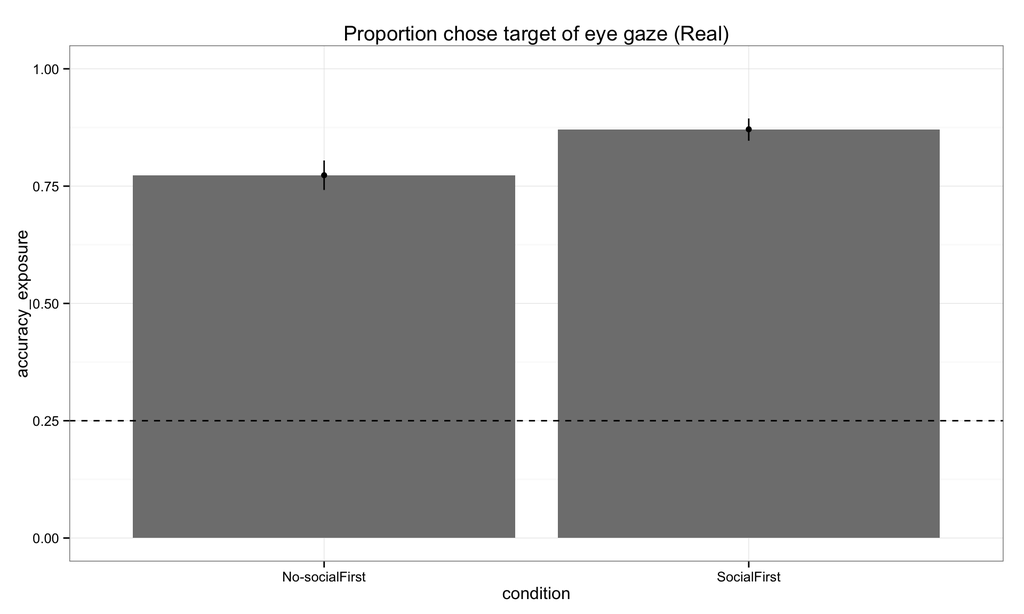

```r
ms_expo <- df_exposure %>%
      group_by(condition, condition_trial) %>%
      summarise(accuracy_exposure = mean(correct),
                ci_low = ci.low(correct),
                ci_high = ci.high(correct))

ms_expo$condition <- factor(ms_expo$condition)

acc_exp_live <- ggplot(data=ms_expo,
                       aes(x=condition, y=accuracy_exposure)) +
      geom_bar(stat="identity", fill = I("grey50")) +
      geom_pointrange(aes(ymin=accuracy_exposure-ci_low,
                          ymax=accuracy_exposure+ci_high), width = .1) +
      geom_hline(yintercept=0.25, linetype = "dashed") +
      scale_y_continuous(limits=c(0,1)) +
      ggtitle("Proportion chose target of eye gaze (Real)")

acc_exp_live
```

Now we do the same thing, but filtering out the subjects who performed below chance levels selecting the target of eye gaze.

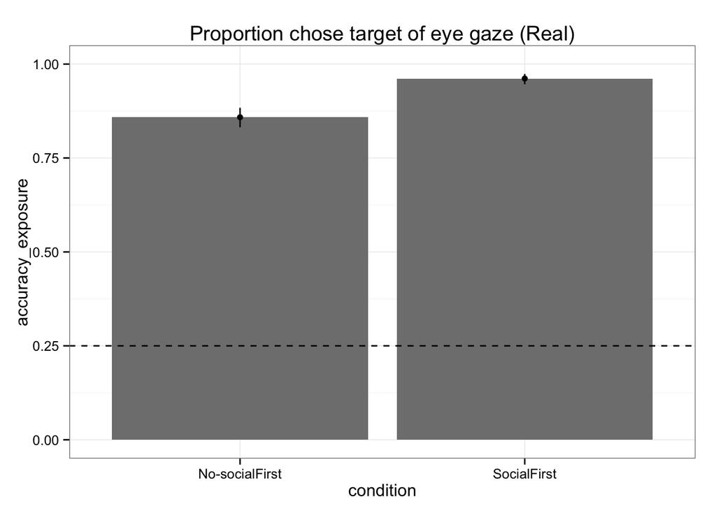

```r
ms_expo_filt <- df_exposure_filt %>%
      group_by(condition, condition_trial) %>%
      summarise(accuracy_exposure = mean(correct),
                ci_low = ci.low(correct),
                ci_high = ci.high(correct))

ms_expo_filt$condition <- factor(ms_expo_filt$condition)

acc_exp_live_filt <- ggplot(data=ms_expo_filt,
                       aes(x=condition, y=accuracy_exposure)) +
      geom_bar(stat="identity", fill = I("grey50")) +
      geom_pointrange(aes(ymin=accuracy_exposure-ci_low,
                          ymax=accuracy_exposure+ci_high), width = .1) +
      geom_hline(yintercept=0.25, linetype = "dashed") +
      scale_y_continuous(limits=c(0,1)) +
      ggtitle("Proportion chose target of eye gaze (Real)")

acc_exp_live_filt
```

Anayze RT on exposure trials.

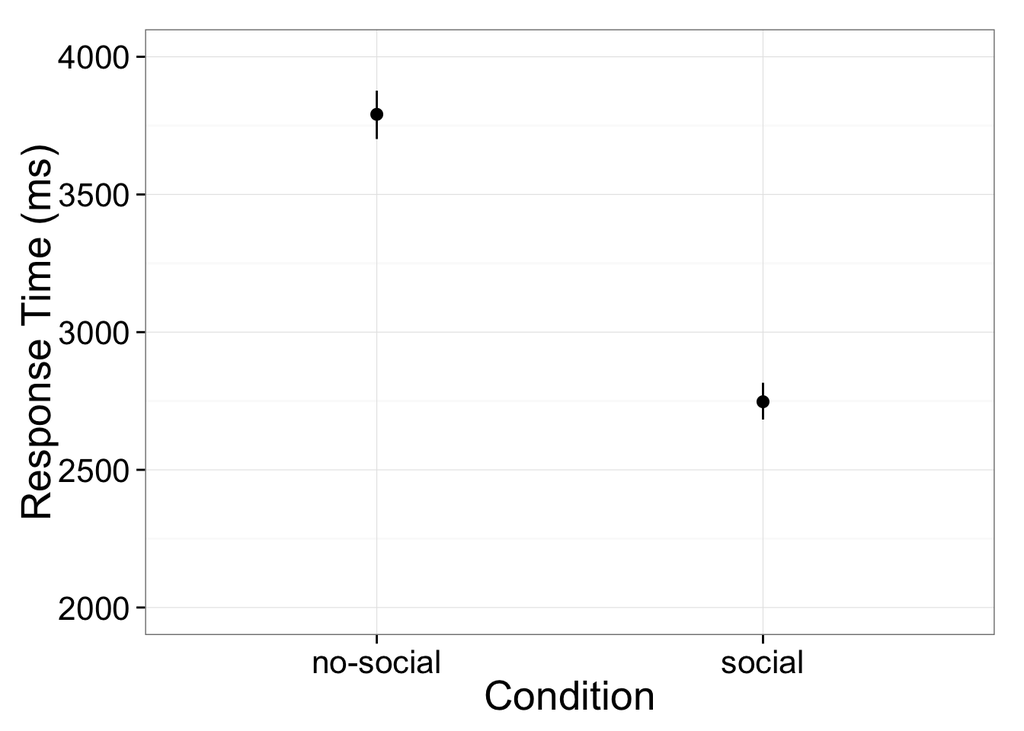

```r
df_exposure_filt_all <- filter(df_live,
                           trial_cat == "exposure",
                           mean_acc_exp > 0.25,
                           include_good_rt == 1)

ms_rt_expo_filt <- df_exposure_filt_all %>%
      group_by(condition_trial) %>%
      summarise(rt_exposure = mean(rt),
                ci_low = ci.low(rt),
                ci_high = ci.high(rt))

ms_rt_expo_filt$condition <- factor(ms_rt_expo_filt$condition)

ggplot(ms_rt_expo_filt,
       aes(x=condition_trial, y=rt_exposure)) +
      geom_point(size=3) +
      geom_pointrange(aes(ymin=rt_exposure - ci_low,
                          ymax=rt_exposure + ci_high), width = .1) +
      scale_y_continuous(limits=c(2000,4000)) +
      ylab("Response Time (ms)") +
      xlab("Condition") +
      theme(text = element_text(size=20))
```

```
## stat_bin: binwidth defaulted to range/30. Use 'binwidth = x' to adjust this.
## stat_bin: binwidth defaulted to range/30. Use 'binwidth = x' to adjust this.
```

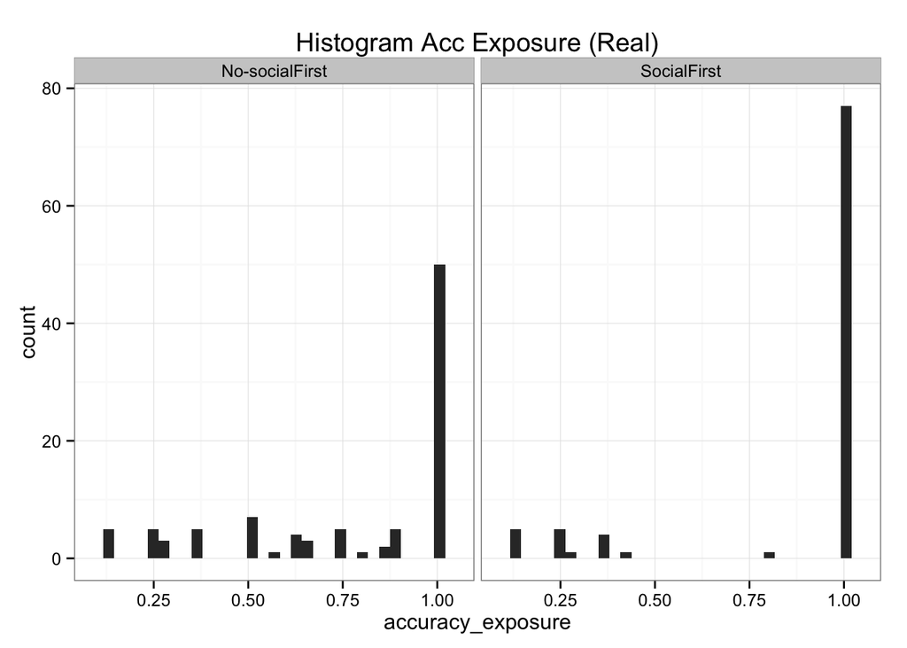

```r
mss_expo <- df_exposure %>%
      group_by(condition, condition_trial, subids) %>%
      summarise(accuracy_exposure = mean(correct))

hist_expo_live <- qplot(accuracy_exposure, geom="bar", facets=.~condition,
                        main = c("Histogram Acc Exposure (Real)"), data=mss_expo)

hist_expo_live
```

Explore subjects performance over trials.

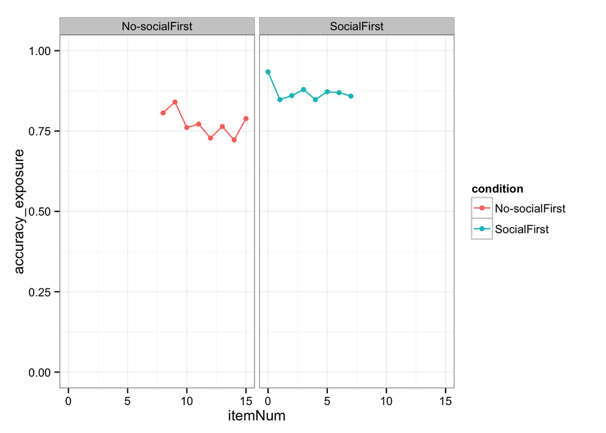

```r
dss <- df_exposure %>%
      group_by(condition, condition_trial, itemNum) %>%
      summarise(accuracy_exposure = mean(correct))

qplot(itemNum, accuracy_exposure, col=condition, facets=.~condition,
      geom=c("point","line"),
      data=dss) +
      scale_y_continuous(limits=c(0,1))
```

#### Accuracy on test trials within subjects experiment

Test accuracy computations with different filters.

Set up filters

```r
# just RT filter
df_test <- filter(df_test,
                      trial_cat == "test",
                      include_good_rt == 1)

# RT, subject level and trial level filter
df_test_filt <- filter(df_test,
                       trial_cat == "test",
                       mean_acc_exp > 0.25 ,
                       include_good_rt == 1,
                       correct_exposure == T | condition_trial == "no-social")
```

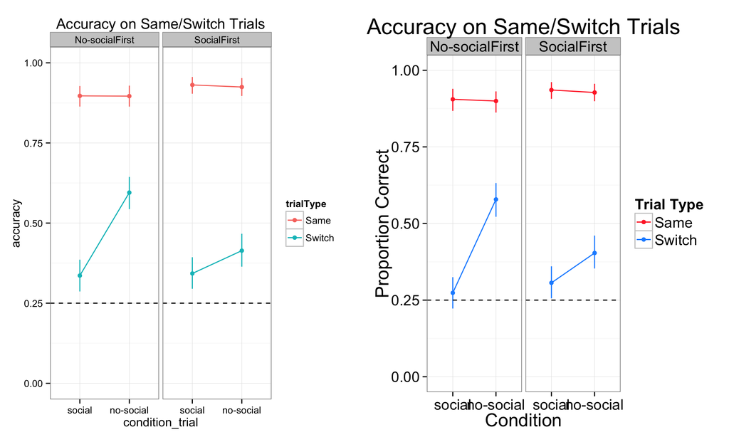

```r
# No filter
ms_test <- df_test %>%
      group_by(condition, condition_trial, trialType) %>%
      summarise(accuracy = mean(correct),
                ci_low = ci.low(correct),
                ci_high = ci.high(correct))

ms_test$condition <- factor(ms_test$condition)
ms_test$condition_trial <- factor(ms_test$condition_trial,
                                  levels = c("social", "no-social"))

acc_test_plot <- ggplot(ms_test,
                        aes(x=condition_trial, y=accuracy,
                            group=trialType, colour=trialType)) +
      geom_point(size=2) +
      geom_line() +
      geom_pointrange(aes(ymin=accuracy - ci_low,
                          ymax=accuracy + ci_high), width = .1) +
      geom_hline(yintercept=0.25, linetype = "dashed") +
      scale_y_continuous(limits=c(0,1)) +
      facet_wrap(~condition) +
      ggtitle("Accuracy on Same/Switch Trials")

# Filtered
ms_test_filt <- df_test_filt %>%
      group_by(condition, condition_trial, trialType) %>%
      summarise(accuracy = mean(correct),
                ci_low = ci.low(correct),
                ci_high = ci.high(correct))

ms_test_filt$condition <- factor(ms_test_filt$condition)
ms_test_filt$condition_trial <- factor(ms_test_filt$condition_trial,
                                  levels = c("social", "no-social"))

acc_test_filt_plot <- ggplot(ms_test_filt,
                             aes(x=condition_trial, y=accuracy,
                                 group=trialType, colour=trialType)) +
      geom_point(size=2) +
      geom_line() +
      geom_pointrange(aes(ymin=accuracy - ci_low,
                          ymax=accuracy + ci_high), width=.1) +
      geom_hline(yintercept=0.25, linetype = "dashed") +
      scale_y_continuous(limits=c(0,1)) +
      facet_wrap(~condition) +
      ggtitle("Accuracy on Same/Switch Trials") +
      scale_colour_manual(values=c("firebrick1", "dodgerblue")) +
      xlab("Condition") +
      ylab("Proportion Correct") +
      labs(colour = "Trial Type") +
      theme(text = element_text(size=18))


multiplot(acc_test_plot, acc_test_filt_plot, cols = 2)
```

Now do the same accuracy computation but collapse across blocks

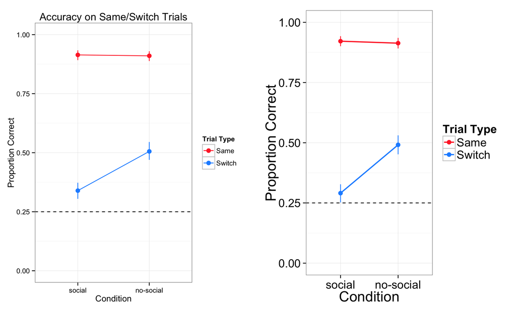

```r
##Subject level
ms_test_collapsed <- df_test %>%
      group_by(condition_trial, trialType) %>%
      summarise(accuracy = mean(correct),
                ci_low = ci.low(correct),
                ci_high = ci.high(correct))

ms_test_collapsed$condition_trial <- factor(ms_test_collapsed$condition_trial,
                                  levels = c("social", "no-social"))

acc_test_plot_2 <- ggplot(ms_test_collapsed,
                        aes(x=condition_trial, y=accuracy,
                            group=trialType, colour=trialType)) +
      geom_point(size=3) +
      geom_line() +
      geom_pointrange(aes(ymin=accuracy - ci_low,
                          ymax=accuracy + ci_high), width = .1) +
      geom_hline(yintercept=0.25, linetype = "dashed") +
      scale_y_continuous(limits=c(0,1)) +
      ggtitle("Accuracy on Same/Switch Trials") +
      scale_colour_manual(values=c("firebrick1", "dodgerblue")) +
      xlab("Condition") +
      ylab("Proportion Correct") +
      labs(colour = "Trial Type")

# Filtered
ms_test_filt_collapsed <- df_test_filt %>%
      group_by(condition_trial, trialType) %>%
      summarise(accuracy = mean(correct),
                ci_low = ci.low(correct),
                ci_high = ci.high(correct))

ms_test_filt_collapsed$condition_trial <- factor(ms_test_filt_collapsed$condition_trial,
                                  levels = c("social", "no-social"))

acc_test_filt_plot_2 <- ggplot(ms_test_filt_collapsed,
                             aes(x=condition_trial, y=accuracy,
                                 group=trialType, colour=trialType)) +
      geom_point(size = 3) +
      geom_line(size = 0.8) +
      geom_pointrange(aes(ymin=accuracy - ci_low,
                          ymax=accuracy + ci_high), width=.1) +
      geom_hline(yintercept=0.25, linetype = "dashed") +
      scale_y_continuous(limits=c(0,1)) +
      scale_colour_manual(values=c("firebrick1", "dodgerblue")) +
      xlab("Condition") +
      ylab("Proportion Correct") +
      labs(colour = "Trial Type") +
      theme(text = element_text(size=20))


multiplot(acc_test_plot_2, acc_test_filt_plot_2, cols = 2)
```

Look at performance on same/switch trials over time in the task.

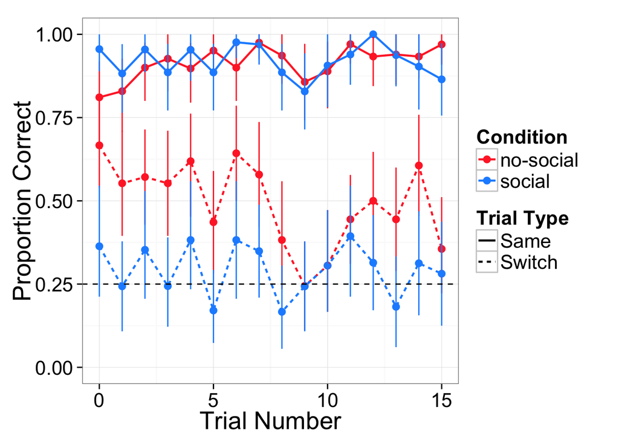

```r
ms_test_trials <- df_test_filt %>%
      group_by(condition_trial, trialType, itemNum) %>%
      summarise(accuracy = mean(correct),
                ci_low = ci.low(correct),
                ci_high = ci.high(correct))

ggplot(ms_test_trials,
       aes(x=itemNum, y=accuracy,
           colour=condition_trial)) +
      geom_point(size = 3) +
      geom_line(size = 0.8, aes(linetype=trialType)) +
      geom_pointrange(aes(ymin=accuracy - ci_low,
                          ymax=accuracy + ci_high), width=.1) +
      geom_hline(yintercept=0.25, linetype = "dashed") +
      scale_y_continuous(limits=c(0,1)) +
      scale_colour_manual(values=c("firebrick1", "dodgerblue")) +
      xlab("Trial Number") +
      ylab("Proportion Correct") +
      labs(colour = "Condition", linetype = "Trial Type") +
      theme(text = element_text(size=20))
```

RT on test trials

```r
ms_test_filt_rt <- df_test_filt %>%
      group_by(condition_trial, trialType) %>%
      summarise(rt_test = mean(rt),
                ci_low = ci.low(rt),
                ci_high = ci.high(rt))

ms_test_filt_rt$condition_trial <- factor(ms_test_filt_rt$condition_trial,
                                  levels = c("social", "no-social"))

rt_test_filt_plot <- ggplot(ms_test_filt_rt,
                             aes(x=condition_trial, y=rt_test,
                                 group=trialType, colour=trialType)) +
      geom_point(size = 3) +
      geom_line(size = 0.8) +
      geom_pointrange(aes(ymin=rt_test - ci_low,
                          ymax=rt_test + ci_high), width=.1) +
      scale_colour_manual(values=c("firebrick1", "dodgerblue")) +
      xlab("Condition") +
      ylab("Response Time") +
      labs(colour = "Trial Type") +
      theme(text = element_text(size=20))
```

##### Model the data

```r
# unfiltered
m1_within_unfilt <- glmer(correct ~ trialType * condition_trial + (trialType | subids),
            data = df_test,
            family=binomial)
summary(m1_within_unfilt)
```

```
## Generalized linear mixed model fit by maximum likelihood (Laplace
##   Approximation) [glmerMod]
##  Family: binomial  ( logit )
## Formula: correct ~ trialType * condition_trial + (trialType | subids)
##    Data: df_test
##
##      AIC      BIC   logLik deviance df.resid
##   2673.2   2715.0  -1329.6   2659.2     2886
##
## Scaled residuals:
##     Min      1Q  Median      3Q     Max
## -4.4123 -0.6110  0.1599  0.4367  2.2532
##
## Random effects:
##  Groups Name            Variance Std.Dev. Corr
##  subids (Intercept)     2.722    1.650
##         trialTypeSwitch 2.222    1.491    -0.89
## Number of obs: 2893, groups:  subids, 190
##
## Fixed effects:
##                                        Estimate Std. Error z value
## (Intercept)                            3.250145   0.262986  12.359
## trialTypeSwitch                       -3.234671   0.269772 -11.990
## condition_trialsocial                  0.002366   0.208526   0.011
## trialTypeSwitch:condition_trialsocial -0.766115   0.238671  -3.210
##                                       Pr(>|z|)
## (Intercept)                            < 2e-16 ***
## trialTypeSwitch                        < 2e-16 ***
## condition_trialsocial                  0.99095
## trialTypeSwitch:condition_trialsocial  0.00133 **
## ---
## Signif. codes:  0 '***' 0.001 '**' 0.01 '*' 0.05 '.' 0.1 ' ' 1
##
## Correlation of Fixed Effects:
##             (Intr) trlTyS cndtn_
## trlTypSwtch -0.935
## cndtn_trlsc -0.411  0.400
## trlTypSwt:_  0.359 -0.447 -0.873
```

```r
# subject level and trial level filter
m1_within <- glmer(correct ~ trialType * condition_trial + (trialType | subids),
            data = df_test_filt,
            family=binomial)
summary(m1_within)
```

```
## Generalized linear mixed model fit by maximum likelihood (Laplace
##   Approximation) [glmerMod]
##  Family: binomial  ( logit )
## Formula: correct ~ trialType * condition_trial + (trialType | subids)
##    Data: df_test_filt
##
##      AIC      BIC   logLik deviance df.resid
##   2209.6   2250.2  -1097.8   2195.6     2410
##
## Scaled residuals:
##     Min      1Q  Median      3Q     Max
## -4.7038 -0.6171  0.1664  0.3430  2.3119
##
## Random effects:
##  Groups Name            Variance Std.Dev. Corr
##  subids (Intercept)     2.131    1.460
##         trialTypeSwitch 1.698    1.303    -0.91
## Number of obs: 2417, groups:  subids, 166
##
## Fixed effects:
##                                       Estimate Std. Error z value Pr(>|z|)
## (Intercept)                            3.11722    0.26699  11.675  < 2e-16
## trialTypeSwitch                       -3.16492    0.27496 -11.510  < 2e-16
## condition_trialsocial                  0.05991    0.22858   0.262 0.793255
## trialTypeSwitch:condition_trialsocial -0.97845    0.26207  -3.734 0.000189
##
## (Intercept)                           ***
## trialTypeSwitch                       ***
## condition_trialsocial
## trialTypeSwitch:condition_trialsocial ***
## ---
## Signif. codes:  0 '***' 0.001 '**' 0.01 '*' 0.05 '.' 0.1 ' ' 1
##
## Correlation of Fixed Effects:
##             (Intr) trlTyS cndtn_
## trlTypSwtch -0.938
## cndtn_trlsc -0.414  0.402
## trlTypSwt:_  0.362 -0.446 -0.871
```